# KERA Basic Examples

# Installing Keras

Before installing and running the keras package, you must install anaconda in your PC (or any python version, but anaconda is the most convenient). Avoid having multiple installations for python or python IDEs in your machine, as it is often a cause of error in running Keras in R.

The code below double checks the location of anaconda and/or python installed in the machine. In general, it is better to uninstall all instances of keras, reticulate, or tensorflow before installing anaconda and/or running the keras package for the first time.

Failure to locate anaconda or python often results to “loadname space error…” (i.e., R can’t find or import keras despite successfull installation of the package).

```r
# install.packages("reticulate")
library("reticulate")
py_discover_config("keras")
```

```
## python:         C:/Users/bayanivb/AppData/Local/r-miniconda/envs/r-reticulate/python.exe
## libpython:      C:/Users/bayanivb/AppData/Local/r-miniconda/envs/r-reticulate/python38.dll
## pythonhome:     C:/Users/bayanivb/AppData/Local/r-miniconda/envs/r-reticulate
## version:        3.8.13 | packaged by conda-forge | (default, Mar 25 2022, 05:59:00) [MSC v.1929 64 bit (AMD64)]
## Architecture:   64bit
## numpy:          C:/Users/bayanivb/AppData/Local/r-miniconda/envs/r-reticulate/Lib/site-packages/numpy
## numpy_version:  1.22.4
## keras:          C:\Users\bayanivb\AppData\Local\R-MINI~1\envs\R-RETI~1\lib\site-packages\keras\__init__.p
##
## NOTE: Python version was forced by RETICULATE_PYTHON
```

Then, we shall install keras package. The function “install_keras” allows us to install Python packages (tensorflow, keras) and dependencies from RStudio. First time installation takes some time. Keras and tensorflow are interfaces that allow one to conveniently experiment different deep learning architectures and/or algorithms.

```r
# install.packages("keras")
library("keras")
# install_keras() #you only have to do this on your first installation
```

The tidyverse package is for data management.

```r
library("tidyverse")
```

# Building a Neural Net

The typical Keras workflow:

1. Define your training data: **input tensors and target tensors.**
2. Define a network of layers (or model) that maps your inputs to your targets.
3. Configure the learning process by choosing a loss function, an optimizer, and some metrics to monitor.
4. Iterate on your training data by calling the **fit()** method of your model.

For our example, let’s build a neural net for detecting with movies are critically acclaimed by critics/reviews. We will use the movies data set.

```r
library(here)
here()
```

```
## [1] "C:/Users/bayanivb/Documents/Masters/Stat 218/Neural Networks"
```

```r
movie <- read_rds(file = here("MOVIE DATA.rds"))
movie
```

| id | movie | year | ratings | genre | gross | budget | screens | sequel | sentiment | views | likes | dislikes | comments | followers |
| --- | --- | --- | --- | --- | --- | --- | --- | --- | --- | --- | --- | --- | --- | --- |
| 1 | 13 Sins | 2014 | 6.3 | 8 | 9.13e+03 | 4000000 | 45 | NO | NEUTRAL | 3280543 | 4632 | 425 | 636 | 1120000 |
| 2 | 22 Jump Street | 2014 | 7.1 | 1 | 1.92e+08 | 50000000 | 3306 | YES | POSITIVE | 583289 | 3465 | 61 | 186 | 12350000 |
| 3 | 3 Days to Kill | 2014 | 6.2 | 1 | 3.07e+07 | 28000000 | 2872 | NO | NEUTRAL | 304861 | 328 | 34 | 47 | 483000 |
| 4 | 300: Rise of an Empire | 2014 | 6.3 | 1 | 1.06e+08 | 110000000 | 3470 | YES | NEUTRAL | 452917 | 2429 | 132 | 590 | 568000 |
| 5 | A Haunted House 2 | 2014 | 4.7 | 8 | 1.73e+07 | 3500000 | 2310 | YES | NEUTRAL | 3145573 | 12163 | 610 | 1082 | 1923800 |
| 6 | A Long Way Off | 2014 | 4.6 | 3 | 2.90e+04 | 500000 | NA | NO | NEUTRAL | 91137 | 112 | 7 | 1 | 310000 |
| 7 | A Million Ways to Die in the West | 2014 | 6.1 | 8 | 4.26e+07 | 40000000 | 3158 | NO | NEUTRAL | 3013011 | 9595 | 419 | 1020 | 8153000 |
| 8 | A Most Violent Year | 2014 | 7.1 | 1 | 5.75e+06 | 20000000 | 818 | NO | POSITIVE | 1854103 | 2207 | 197 | 593 | 130655 |
| 9 | A Walk Among the Tombstones | 2014 | 6.5 | 10 | 2.60e+07 | 28000000 | 2714 | NO | POSITIVE | 2213659 | 2210 | 419 | 382 | 125646 |
| 10 | About Last Night | 2014 | 6.1 | 8 | 4.86e+07 | 12500000 | 2253 | NO | NEUTRAL | 5218079 | 11709 | 532 | 770 | 21697300 |

[output cut: 221 more lines]

```r
movie_prep <- movie%>%
                  transmute(id, ratings = (ratings >= 7)*1, gross, budget, screens,
                            sentiment = 1*(sentiment == "POSITIVE"), views, likes,
                            dislikes, comments, followers) %>%
                  na.omit()

movie_prep
```

| id | ratings | gross | budget | screens | sentiment | views | likes | dislikes | comments | followers |
| --- | --- | --- | --- | --- | --- | --- | --- | --- | --- | --- |
| 1 | 0 | 9.13e+03 | 4000000 | 45 | 0 | 3280543 | 4632 | 425 | 636 | 1120000 |
| 2 | 1 | 1.92e+08 | 50000000 | 3306 | 1 | 583289 | 3465 | 61 | 186 | 12350000 |
| 3 | 0 | 3.07e+07 | 28000000 | 2872 | 0 | 304861 | 328 | 34 | 47 | 483000 |
| 4 | 0 | 1.06e+08 | 110000000 | 3470 | 0 | 452917 | 2429 | 132 | 590 | 568000 |
| 5 | 0 | 1.73e+07 | 3500000 | 2310 | 0 | 3145573 | 12163 | 610 | 1082 | 1923800 |
| 7 | 0 | 4.26e+07 | 40000000 | 3158 | 0 | 3013011 | 9595 | 419 | 1020 | 8153000 |
| 8 | 1 | 5.75e+06 | 20000000 | 818 | 1 | 1854103 | 2207 | 197 | 593 | 130655 |
| 9 | 0 | 2.60e+07 | 28000000 | 2714 | 1 | 2213659 | 2210 | 419 | 382 | 125646 |
| 10 | 0 | 4.86e+07 | 12500000 | 2253 | 0 | 5218079 | 11709 | 532 | 770 | 21697300 |
| 11 | 1 | 3.50e+08 | 58800000 | 3555 | 1 | 3927600 | 13143 | 573 | 3134 | 24300 |

[output cut: 177 more lines]

Prepare the tensor objects. In this case, we have to prepare the input tensor. Tensor is simply the an array object used as a input layer or output layer of a neural net. Since it is an array, the elements of a tensor should be homogeneous (all numeric, all text, etc.). And so, categorical variables should be dummified!. In addition, it is allowed to have high dimensional tensors (3D and up). In fact, that is the case for image recognition. That’s why arrays are the suited objects.

Don’t forget to set aside a validation set. Since we only have few samples, we will set aside 50 observations for validation set. In addition, you must have separate arrays for the target and the predictors or input tensor. Take note, deep learning is ideal when you have so many samples. Hence, holding out some observations should not be a problem.

```r
set.seed(1234)
test_movies <- movie_prep %>%
                  group_by(ratings) %>%
                  sample_n(size = 25, replace = F) %>%
                  ungroup()

train_movies <- movie_prep %>%
                  anti_join(test_movies, by = "id")

train_movies
```

| id | ratings | gross | budget | screens | sentiment | views | likes | dislikes | comments | followers |
| --- | --- | --- | --- | --- | --- | --- | --- | --- | --- | --- |
| 1 | 0 | 9.13e+03 | 4000000 | 45 | 0 | 3280543 | 4632 | 425 | 636 | 1120000 |
| 2 | 1 | 1.92e+08 | 50000000 | 3306 | 1 | 583289 | 3465 | 61 | 186 | 12350000 |
| 3 | 0 | 3.07e+07 | 28000000 | 2872 | 0 | 304861 | 328 | 34 | 47 | 483000 |
| 4 | 0 | 1.06e+08 | 110000000 | 3470 | 0 | 452917 | 2429 | 132 | 590 | 568000 |
| 7 | 0 | 4.26e+07 | 40000000 | 3158 | 0 | 3013011 | 9595 | 419 | 1020 | 8153000 |
| 9 | 0 | 2.60e+07 | 28000000 | 2714 | 1 | 2213659 | 2210 | 419 | 382 | 125646 |
| 10 | 0 | 4.86e+07 | 12500000 | 2253 | 0 | 5218079 | 11709 | 532 | 770 | 21697300 |
| 12 | 0 | 1.52e+07 | 30000000 | 1762 | 0 | 519327 | 963 | 94 | 70 | 386400 |
| 13 | 0 | 8.43e+07 | 6500000 | 3185 | 0 | 19032902 | 38810 | 4382 | 4392 | 19420105 |
| 14 | 0 | 8.59e+07 | 65000000 | 3116 | 0 | 930006 | 5150 | 707 | 1484 | 5130800 |

[output cut: 127 more lines]

```r
train_x_movies <- train_movies %>% select(-id, -ratings) %>% as.matrix()
train_y_movies <- train_movies %>% select(ratings) %>% as.matrix()
test_x_movies  <- test_movies %>% select(-id, -ratings) %>% as.matrix()
test_y_movies  <- test_movies %>% select(ratings) %>% as.matrix()
```

```r
dim(train_x_movies)
```

```
## [1] 137   9
```

Now, we have the tensors!. Next, experiment, code and evaluate different models.

## Define a Model

Specify the structure of the model.

```r
model <- keras_model_sequential() %>%
            layer_dense(units = 5, activation = "relu", input_shape = c(9)) %>%
            layer_dense(units = 5, activation = "relu") %>%
            #layer_activity_regularization(l2 = 2) %>%
            layer_dense(units = 1, activation = "sigmoid")
```

```
## Loaded Tensorflow version 2.9.1
```

Trying out different combinations of activation functions for the model

```r
model_relu <- keras_model_sequential() %>%
            layer_dense(units = 5, activation = "relu", input_shape = c(9)) %>%
            layer_dense(units = 5, activation = "relu") %>%
            #layer_activity_regularization(l2 = 2) %>%
            layer_dense(units = 1, activation = "relu")
```

```r
model_sigmoid <- keras_model_sequential() %>%
            layer_dense(units = 5, activation = "sigmoid", input_shape = c(9)) %>%
            layer_dense(units = 5, activation = "sigmoid") %>%
            #layer_activity_regularization(l2 = 2) %>%
            layer_dense(units = 1, activation = "sigmoid")
```

## Compile

Identify the optimiser, Loss, metrics

Possible losses are:

+mean_squared_error +mean_absolute_error +mean_absolute_percentage_error +mean_squared_logarithmic_error +squared_hinge +hinge +categorical_crossentropy +sparse_categorical_crossentropy +binary_crossentropy +kullback_leibler_divergence +poisson +cosine_proximity

Possible metrics are:

+accuracy +binary_accuracy +categorical_accuracy +sparse_categorical_accuracy +top_k_categorical_accuracy

```r
model %>% compile(
              optimizer = optimizer_rmsprop(learning_rate = 0.001), #adam
              loss = "binary_crossentropy",
              metrics = c("accuracy")
              )
```

```r
model_relu %>% compile(
              optimizer = optimizer_rmsprop(learning_rate = 0.001), #adam
              loss = "binary_crossentropy",
              metrics = c("accuracy")
              )
```

```r
model_sigmoid %>% compile(
              optimizer = optimizer_rmsprop(learning_rate = 0.001), #adam
              loss = "binary_crossentropy",
              metrics = c("accuracy")
              )
```

## Fit

Fit the model. It executes the optimiser and begins the training.

```r
history <- model %>% fit(
                        train_x_movies,
                        train_y_movies,
                        epochs = 200,
                        batch_size = 16,
                        validation_data = list(test_x_movies, test_y_movies)
                        )
```

Fitting the relu model as well

```r
history_relu <- model_relu %>% fit(
                        train_x_movies,
                        train_y_movies,
                        epochs = 200,
                        batch_size = 16,
                        validation_data = list(test_x_movies, test_y_movies)
                        )
```

And the sigmoid model

```r
history_sigmoid <- model_sigmoid %>% fit(
                        train_x_movies,
                        train_y_movies,
                        epochs = 200,
                        batch_size = 16,
                        validation_data = list(test_x_movies, test_y_movies)
                        )
```

## Evaluate

Evaluate the loss function and accuracy in test and validation.

[figure not shown]

```r
plot(history)
```

[figure not shown]

```r
plot(history_relu)
```

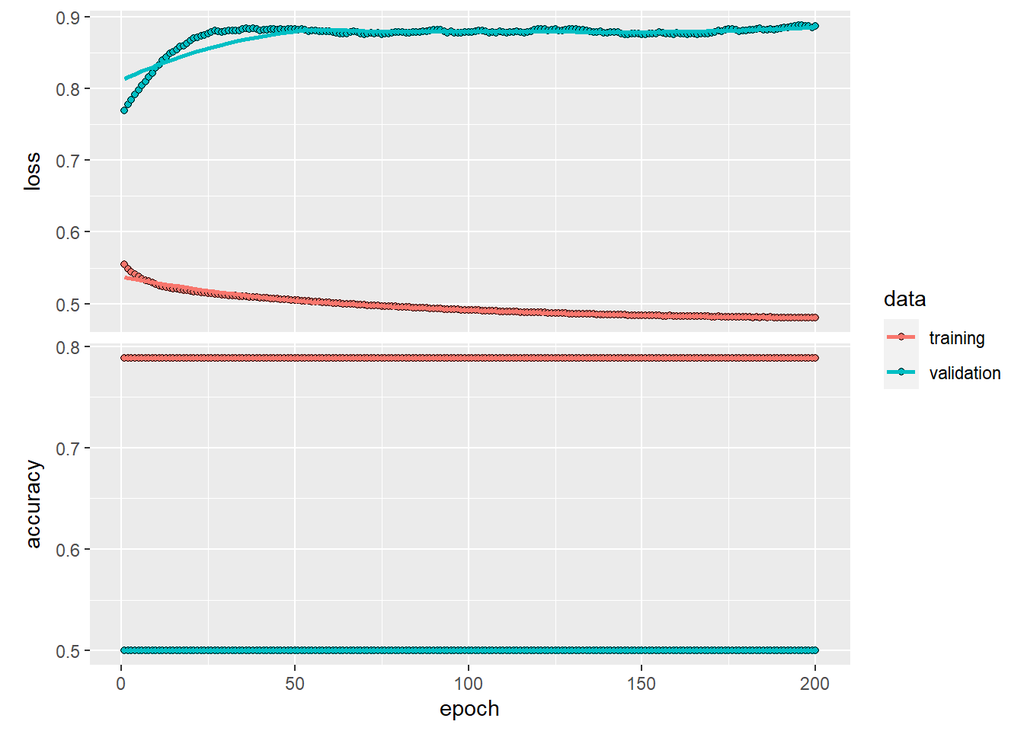

```r
plot(history_sigmoid)
```

## Predict

Predict the target of a new/test data.

```r
pred_ratings <- model %>%
                  predict(test_x_movies)

table("obs" = test_y_movies, "pred" = pred_ratings)
```

```
##    pred
## obs  0 0.420992434024811  1
##   0 15                 1  9
##   1 12                 1 12
```

```r
pred_ratings_relu <- model_relu %>%
                  predict(test_x_movies)

table("obs" = test_y_movies, "pred" = pred_ratings_relu)
```

```
##    pred
## obs 0 35285.375 107454.2265625 204241 295378.5625 306913.84375 431662.15625
##   0 7         0              1      0           0            1            1
##   1 5         1              0      1           1            0            0
##    pred
## obs 466525.84375 548119.875 717202.25 730646.4375 796658.75 828879.875
##   0            1          1         0           1         0          0
##   1            0          0         1           0         1          1
##    pred
## obs 1012928.25 1185429.5 1366220.25 1372236.375 1557264.5 1579718.25 1582815.25
##   0          1         1          0           0         1          1          0
##   1          0         0          1           1         0          0          1
##    pred
## obs 1663801.875 1690680.25 1773555.125 2006239.375 2331348 2804929 2863881
##   0           0          1           0           1       0       0       1
##   1           1          0           1           0       1       1       0
##    pred
## obs 2934345.5 4277011.5 4373982.5 4487705.5 4505112.5 4634057.5 4937716
##   0         1         0         1         1         0         0       0
##   1         0         1         0         0         1         1       1
##    pred
## obs 5449799.5 5493014.5 6513359 7257619.5 9145725
##   0         1         0       1         0       0
##   1         0         1       0         1       1
```

```r
pred_ratings_sigmoid <- model_sigmoid %>%
                  predict(test_x_movies)

table("obs" = test_y_movies, "pred" = pred_ratings_sigmoid)
```

```
##    pred
## obs 0.0856970921158791 0.176071718335152 0.19352687895298 0.228190392255783
##   0                  6                 2                0                 0
##   1                  3                 2                1                 1
##    pred
## obs 0.23882782459259 0.295241951942444
##   0                2                15
##   1                8                10
```